# Gardnerella Strain Metronidazole MICs

Hanna Berman

April 03, 2026

**Purpose:** To assess the minimum inhibitory concentration of metronidazole on *Gardnerella* isolates.

**Protocol:**

- Streak strains onto BHI agar plates with 1% yeast extract and 0.5% dextrose
- Inoculate colonies into 1mL NYC-III media and incubate for 24 hours at 37°C anaerobically (48 hours for strains C0084H9, C0093B3, C0101A1, UM35)
- Measure OD<sub>600</sub> of culture are dilute to 0.1 in PBS
  - If cultures OD<sub>600</sub> is not greater than or equal to 0.1, back dilute 1:100 and incubate another 24 or 48 hours
  - Cultures with OD<sub>600</sub> < 0.1 not used
- Plate lawns (two technical replicates per culture) onto BHI with 1% yeast extract and 0.5% dextrose
- Place a metronidazole MIC test strip into center of plate
- Incubate at 37°C anaerobically for 48 hours
- Observe MIC as lowest dose where growth is inhibited
- Perform again for second biological replicate

```r
library(tidyverse)
library(cowplot)
library(formattable)
library(kableExtra)
`%!in%` <- negate(`%in%`)
```

Short cuts

```r
strains <- c("14018", "315-A", "C0011E4", "JCP7275", "C0084H9", "JCP8108", "JCP8017B", "C0040C2" , "UM35",  "JCP8066", "C0093B3", "AMD", "C0096A1", "C0102A2",  "UM224", "Gv5-1", "C0179B4", "C0056B5", "Gv101", "C0100B2", "C0101A1", "CMW7778B")

species <- c("Gardnerella vaginalis", "Gardnerella lacydonensis", "Gardnerella pickettii", "Gardnerella piotii", "Gardnerella leopoldii", "Gardnerella swidsinskii", "Gardnerella sp. 7", "Gardnerella greenwoodii", "Gardnerella sp. 10", "Gardnerella sp. 11", "Gardnerella sp. 12")

speciesAbbrevs <- c("G. vag.", "G. lac.", "G. pic.", "G. pio.", "G. leo.", "G. swi.", "7", "G. gre.", "10", "11", "12")

metroDoses <- c("0.016", "0.023", "0.032", "0.047", "0.064", "0.094", "0.125", "0.19", "0.25", "0.38", "0.50", "0.75", "1.0", "1.5", "2", "3", "4", "6", "8", "12", "16", "24", "32", "48", "64", "96", "128", "192", "256", ">256")

h48Strains <- c("C0084H9", "C0093B3", "C0101A1", "UM35") # strains with 48-hour incubation period

figureOut <- "../../experiments_figures"
```

Import data and add updated species names

```r
strainIDs  <- read_csv("./data/strainIDs.csv") %>%
    mutate(Species=case_when(Species=="Gardnerella sp. 2"~"Gardnerella lacydonensis",
                           Species=="Gardnerella sp. 3"~"Gardnerella pickettii",
                           Species=="Gardnerella sp. 8"~"Gardnerella greenwoodii",
                           Species %!in% c("Gardnerella sp. 2", "Gardnerella sp. 3", "Gardnerella sp. 8")~Species))

strainODs <-  read_csv("./data/strainODs.csv")

strainMICs <- read_csv("./data/strainMICs.csv")

strainSpecies <- strainIDs %>%
  select(Strain, Species) %>%
  unique
```

Plot settings

```r
theme_set(theme_bw())

speciesColor <- scale_color_manual(values=c("#CC79A7", "#D55E00", "#56B4E9", "#0072B2", "#E69F00", "#009E73",
                                                 "darkgreen", "gold3", "darkred", "darkblue",
                                                 "mediumpurple4"))

speciesFill <- scale_fill_manual(values=c("#CC79A7", "#D55E00", "#56B4E9", "#0072B2", "#E69F00", "#009E73",
                                                 "darkgreen", "gold3", "darkred", "darkblue",
                                                 "mediumpurple4"))
```

# Growth QC by Optical Density

```r
odDF <- strainODs %>%
  left_join(strainIDs) %>%
  with_groups(Strain, mutate, BioRepRank=dense_rank(BioRep)) %>%
  with_groups(c(Strain, BioRepRank), mutate, ODmeasure=as.character(dense_rank(ODdate))) %>%
  mutate(incubationPeriod=case_when(Strain %in% h48Strains~"48",
                                  !(Strain %in% h48Strains)~"24"))
```

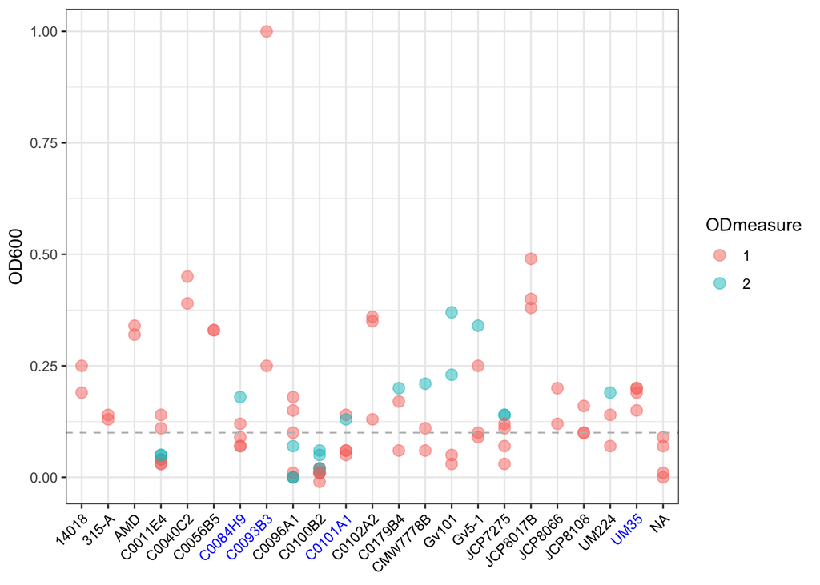

```r
xAxisColors0 <- odDF %>%
  select(Strain, incubationPeriod) %>%
  unique %>%
  arrange(Strain) %>%
  .$incubationPeriod
xAxisColors <- ifelse(xAxisColors0=="24", "black", "blue")

odDF %>%
  ggplot(aes(x=Strain, y=OD, color=ODmeasure)) +
  geom_point(size=3, alpha=0.5) +
  geom_hline(yintercept=0.1, color="gray", linetype=2) +
  scale_x_discrete(drop=FALSE) +
  #scale_shape_manual(values=c(3, 4)) +
  theme(axis.text.x = element_text(angle=45, hjust=1, color=xAxisColors)) +
  labs(x=NULL, y="OD600", shape="Biological Replicate")
```

Strain names listed in blue are in the 48-hour to stationary phase group. Points in teal indicate 1:100 back dilution in fresh NYC-III media from broth culture and subsequent incubation.

# Metronidazole Minimum Inhibitory Concentrations

```r
# format MIC data with strain and sample names
micDF <- strainMICs %>%
    left_join(strainIDs) %>%
    mutate(Sample=paste(Strain, BioRep, TechRep, sep=".")) %>%
    select(Sample, Strain, Species, Number, BioRep, TechRep, MIC, Notes)

#save formatted phenotype data
# micDF %>%
#   select(Sample, Strain, Species, MIC, Notes) %>%
#   write_csv("../formatted_phenotype_data/metro_mic.csv")


micDF1 <- micDF %>%
  filter(MIC != "hard to read",  # filter samples that could not be read
         MIC != "unable to read",
         MIC != "too streaky to read",
         MIC != "Streaky") %>%
  replace_na(list(Notes="None")) %>%
  with_groups(Strain, mutate, BioRepRank=dense_rank(BioRep)) %>%
  mutate(MIC=factor(MIC, levels=metroDoses),
         Strain=factor(Strain, levels=strains),
         BioRepRank=as.character(BioRepRank),
         ColoniesThroughout=str_detect(Notes, "colonies")) # create a true/false column for samples with colonies throughout
```

## Figure 6: Metronidazole MICs

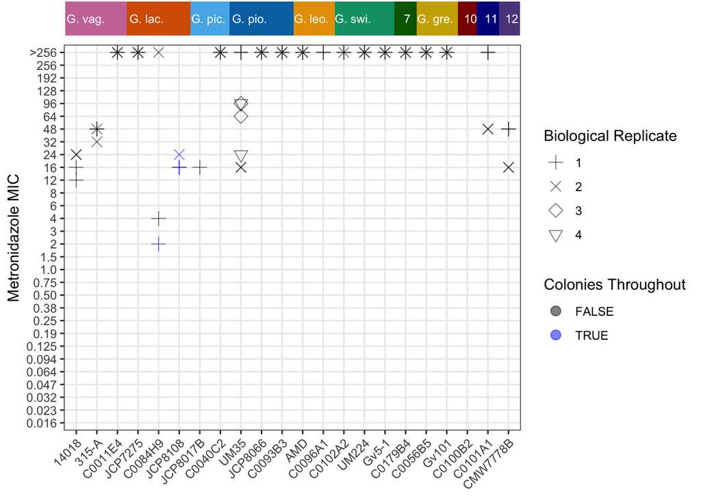

```r
micPlot <- micDF1 %>%
  mutate(Strain=factor(Strain, levels = strains),
         Species=factor(Species, levels = species)) %>%
    ggplot(aes(x=Strain, y=MIC, shape=BioRepRank, color=ColoniesThroughout)) +
    geom_point(size=3, alpha=0.5) +
    scale_x_discrete(drop=FALSE) +
    scale_y_discrete(drop=FALSE) +
    scale_shape_manual(values=c(3, 4, 5, 6)) +
    scale_color_manual(values = c("black", "blue")) +
    theme(axis.text.x = element_text(angle=45, hjust=1)) +
    labs(x=NULL, y="Metronidazole MIC", shape="Biological Replicate", color="Colonies Throughout")

speciesBar <- strainSpecies %>%
  mutate(Strain=factor(Strain, levels = strains),
         Species=factor(Species, levels = species),
         SpeciesLab=factor(Species, levels=species, labels=speciesAbbrevs)) %>%
  with_groups(Species, mutate, num=rank(Strain)) %>%
  mutate(SpeciesLab=case_when(num==1~SpeciesLab,
                              num!=1~"")) %>%
  ggplot() +
    geom_bar(aes(x=Strain, y=1, fill=Species), stat="identity", width=1.1) +
    geom_text(aes(x=Strain, y=0.5, label=SpeciesLab), color="white", hjust = 0.25, size=3) +
    speciesFill +
    theme_void() +
    theme(legend.position = "none")

plot_grid(speciesBar, micPlot, ncol=1, rel_heights = c(0.08, 1),  align = "v", axis = "lr")
```

```r
#ggsave(file.path(figureOut, paste(Sys.Date(), "Figure6_metro_mic.png", sep="_")))
```

The MIC of most strains was >256. Results were reproduced with most strains. UM35 displayed variability among biological replicates. The MIC for biological replicate 1 was >256 and 16 for replicate 2. Two additional biological replicates yielded results between these values: MICs of 24, 64, 96.

Points that are labeled in blue are cases where there was no lawn past the MIC but there were colonies. These occurred in two isolates in *Gardnerella Gardnerella lacydonensis*. One of these isolates, C0084H9 displayed one biological replicate with this result and one with an MIC >256. The third *G. lacydonensis* isolate, JCP7275 had an MIC of >256.

## Table 2: MIC Ranges and Susceptibility of Metronidazole

```r
# Summary table
MICtable <- micDF1 %>%
  mutate(MIC = as.character(MIC),
         MICnum = str_extract(MIC, "[^>]+$") %>% as.numeric()) %>% # create a numeric column of MIC
  group_by(Strain, Species) %>%
  summarize(minMIC=min(MICnum), maxMIC=max(MICnum), CT=any(ColoniesThroughout==TRUE)) %>%
  mutate(`Metronidazole resistance`=case_when(minMIC>=32 & maxMIC>=32 & CT==FALSE ~ "+",
                             minMIC<32 & maxMIC<32 & CT==FALSE ~ "-",
                             minMIC<32 & maxMIC >= 32 ~ "variable",
                             CT==TRUE ~ "variable"),
         minMIC=as.character(minMIC),
         maxMIC=as.character(maxMIC),
         minMIC=paste0("[", minMIC, "]"),
         maxMIC=paste0("[", maxMIC, "]"),
         minMIC=case_when(minMIC=="[256]" ~ paste0(">", minMIC),
                          TRUE~minMIC),
         maxMIC=case_when(maxMIC=="[256]" ~ paste0(">", maxMIC),
                          TRUE~maxMIC),
         `MIC range`=case_when(minMIC!=maxMIC ~ paste(minMIC, maxMIC, sep=" - "),
                               minMIC==maxMIC ~ maxMIC),
         `Colonies`=case_when(CT==TRUE~"*",
                              CT==FALSE~"")) %>%
  select(Species, Strain, `MIC range`, `Metronidazole resistance`, Colonies) %>%
  kbl(caption="Table 2. Minimum inhibitory concentration and resistance of metronidazole") %>%
  kable_classic(full_width=TRUE, html_font = "Arial")

MICtable
```

Table 2. Minimum inhibitory concentration and resistance of metronidazole

Species

Strain

MIC range

Metronidazole resistance

Colonies

Gardnerella vaginalis

14018

[12] - [24]

Gardnerella vaginalis

315-A

[32] - [48]

Gardnerella vaginalis

C0011E4

>[256]

Gardnerella lacydonensis

JCP7275

>[256]

Gardnerella lacydonensis

C0084H9

[2] - >[256]

variable

Gardnerella lacydonensis

JCP8108

[16] - [24]

variable

Gardnerella pickettii

JCP8017B

[16]

Gardnerella pickettii

C0040C2

>[256]

Gardnerella piotii

UM35

[16] - >[256]

variable

Gardnerella piotii

JCP8066

>[256]

Gardnerella piotii

C0093B3

>[256]

Gardnerella leopoldii

AMD

>[256]

Gardnerella leopoldii

C0096A1

>[256]

Gardnerella swidsinskii

C0102A2

>[256]

Gardnerella swidsinskii

UM224

>[256]

Gardnerella swidsinskii

Gv5-1

>[256]

Gardnerella sp. 7

C0179B4

>[256]

Gardnerella greenwoodii

C0056B5

>[256]

Gardnerella greenwoodii

Gv101

>[256]

Gardnerella sp. 11

C0101A1

[48] - >[256]

Gardnerella sp. 12

CMW7778B

[16] - [48]

variable

```r
#save_kable(MICtable, file = file.path(figureOut, paste(Sys.Date(), "Table2_MICTable.png", sep="_")), zoom=6)
```

# Missing Replicates

Aimed to have two biological replicates with two technical replicates each, but the following isolates have fewer that two biological replicates:

```r
s1 <- micDF1 %>%
  with_groups(Strain, summarize, n=n_distinct(BioRep)) %>%
  filter(n<2)
s1 %>%
  bind_rows(., list(Strain=setdiff(strainIDs$Strain, micDF1$Strain),n=0)) %>%
  dplyr::rename("n biological replicates"=n) %>%
  formattable
```

| Strain | n biological replicates |
| --- | --- |
| JCP8017B | 1 |
| C0096A1 | 1 |
| C0100B2 | 0 |

Two strains, JCP8017B and C0096A1, have only 1 biological replicate and C0100B2 did not grow well enough to perform the experiment.